# General Assembly DSI Project 4 in R

Isaac Moore

```r
setwd("~/Google Drive/data_science/general_assembly/Projects/DSI_SM_Project4")
```

Load the tidyverse and other libraries

```r
library("tidyverse")
library("rvest")
require(scales)
```

```r
test <- read_html("https://www.indeed.com/jobs?q=data+analyst&l=Los+Angeles%2C+CA") %>%
        html_nodes(xpath = '//*[row result"]') %>%
        html_text()
```

```
Invalid predicate [1206]xmlXPathEval: evaluation failed
```

```r
test
```

```
character(0)
```

```r
# cast <- lego_movie %>%
#   html_nodes("#titleCast .itemprop span") %>%
#   html_text()
# cast
```

Using the example dataset provided.

```r
raw_data <- read_csv("indeed-scraped-job-postings.csv")
df <- raw_data
head(df)
```

| city | company | salary | summary | title | parsed_salary |
| --- | --- | --- | --- | --- | --- |
| San+Francisco | MarkMonitor | $180,000 a year | Data skills (SQL, Hive, Pig). Applying machine learning to classification problems on unstructured data. MarkMonitor&mdash;the world leader in brand protection... | Data Scientist | 180000 |
| San+Francisco | Workbridge Associates | $130,000 - $180,000 a year | 3+ years of industry experience in a data science or data engineering role. Strong coding skills in data science languages (R, Python).... | Senior Data Scientist | 155000 |
| San+Francisco | Mines.io | $80,000 - $120,000 a year | We are looking for a data scientist/developer to fill a cross-functional role on our small team. We expect you to be able to work and experiment with large data... | Full-Stack Data Scientist | 100000 |
| San+Francisco | Workbridge Associates | $150,000 - $180,000 a year | In this position you will share programming and mathematical challenges with fellow data scientists. A San Francisco-based retail startup is looking to bring on... | Data Scientist | 165000 |
| San+Francisco | Smith Hanley Associates | $140,000 a year | This person will recruit, build and lead a team of Data Scientists. Top technology firm in the Bay Area seeks a Data Scientist for a leadership role in consumer... | Data Scientist | 140000 |
| San+Francisco | HSF Consulting | $300,000 a year | Teams included Data Services(including data engineering and data warehouse developers), Data Operations, and Data Science. Data lead at data company:.... | VP of Data Services | 300000 |

```r
nrow(df)
```

```
[1] 4791
```

```r
ncol(df)
```

```
[1] 6
```

```r
df %>% filter(!is.na(parsed_salary)) %>%
        group_by(city) %>%
        summarise(mean_salary = mean(parsed_salary))
```

| city | mean_salary |
| --- | --- |
| Austin | 17601.66 |
| Chicago | 127431.47 |
| New+York | 139601.54 |
| San+Francisco | 137589.80 |
| Seattle | 33968.24 |

```r
# avg_salary <- mean(subset(df, !is.na(parsed_salary))$parsed_salary)
a <- which(is.na(df$parsed_salary))
df[a, ]
```

[output not shown]

```r
# weekdays <- 52*5
# salary <- (650+900) / 2
# fill_salary <- weekdays * salary
# df[a, ]$parsed_salary <- fill_salary
```

Omit na’s from the dataframe.

```r
df2 <- df %>% na.omit()
nrow(df2)
```

```
[1] 4789
```

```r
ncol(df2)
```

```
[1] 6
```

Not many rows dropped.

```r
df2 %>% group_by(city) %>%
        summarise(mean_salary = mean(parsed_salary))
```

| city | mean_salary |
| --- | --- |
| Austin | 17601.66 |
| Chicago | 127431.47 |
| New+York | 139601.54 |
| San+Francisco | 137589.80 |
| Seattle | 33968.24 |

Compare salarys by removing duplicate rows in the dataframe.

```r
df2 %>% distinct() %>% group_by(city) %>% summarise(mean_salary = mean(parsed_salary))
```

| city | mean_salary |
| --- | --- |
| Austin | 31928.12 |
| Chicago | 126236.42 |
| New+York | 107147.44 |
| San+Francisco | 134679.95 |
| Seattle | 51787.76 |

remove duplicate rows

```r
df3 <- df2 %>% distinct()
nrow(df3)
```

```
[1] 223
```

```r
ncol(df3)
```

```
[1] 6
```

dropped a lot of rows!

### Checking the descrpencies between Austin/Seattle and the other states.

```r
df3%>% filter(city == "Austin")
```

| city | company | salary | summary | title | parsed_salary |
| --- | --- | --- | --- | --- | --- |
| Austin | TechTank Staffing & Consulting Solutions | $140,000 a year | What are we looking for in this Data Scientist Programmer/Specialist:. Data Scientists - Not necessarily picking apart data models but being able to find a good... | Data Scientist Programmer/Specialist | 140000.0 |
| Austin | University of Texas at Austin | $8,333 a month | Development of tools for quantitative stratigraphic analysis and data analysis/database management. We seek a clastic stratigrapher with strengths in... | Research Scientist | 8333.0 |
| Austin | University of Texas at Austin | $6,250 - $10,833 a month | Knowledge of digital signal processing, image processing, machine learning, autonomous control or statistical data analysis.... | Engineering Scientist - R and D Algorithm and System Develop... | 8541.5 |
| Austin | University of Texas at Austin | $6,806 a month | Solve problems encountered in interpretation, map generation, and correlating log data with seismic data. Create database projects and assist in the loading of... | Research Engineering/ Scientist Associate IV | 6806.0 |
| Austin | All-In Analytics | $140,000 - $160,000 a year | Senior Deep Learning Data Scientist. Forecasting, Statistical Modeling, building new data driven products.... | Senior Deep Learning Data Scientist | 150000.0 |
| Austin | University of Texas at Austin | $7,083 - $9,166 a month | Provide technical and research focused leadership and participate in a small, dynamic team of customer focused scientists.... | Research Associate - R and D Data Scientist | 8124.5 |
| Austin | University of Texas at Austin | $5,400 - $6,500 a month | Experience with processing and analyzing GNSS data. Perform processing and detailed analysis of data collected by GPS/GNSS receivers.... | Engineering Scientist Associate - GNSS Analyst Associate | 5950.0 |
| Austin | Texas Department of Public Safety | $3,763 - $5,665 a month | Develop plans, policies, and procedures for analyzing and interpreting statistical data. Work involves coordinating the planning, analysis, and presentation of... | Statistician III-IV, HSOC, THP-Austin | 4714.0 |
| Austin | University of Texas at Austin | $5,400 - $6,500 a month | Data analysis for space weather remediation. Demonstrated proficiency in software development and knowledge of statistical characterization data sets.... | Engineering Scientist Associate - R and D Software Developer | 5950.0 |
| Austin | Dept of State Health Services | $4,599 - $5,333 a month | Examples include consulting with other public health staff and scientists and serving on data workgroups. Provides recommendations for implementing data quality... | Linkage Specialist | 4966.0 |

[output cut: 19 more lines]

Monthly salaries are mixed in with Yearly salaries.

```r
year_salary(df3$parsed_salary)
```

```
  [1] 180000.0 155000.0 100000.0 165000.0 140000.0 300000.0 125000.0 130000.0 160000.0
 [10] 162500.0  46200.0 150000.0  47406.0 155000.0 140000.0 120000.0 145000.0 150000.0
 [19] 170000.0 140000.0  74550.0  65000.0 227500.0 100000.0  55200.0 120000.0 145000.0
 [28] 152500.0 180000.0 135000.0 130000.0 160000.0 175000.0 125000.0 200000.0  30000.0
 [37] 180000.0  49012.0 137500.0 122500.0 140000.0 140000.0 100000.0  97866.5 150000.0
 [46] 200000.0 200000.0  59984.5 105000.0 115000.0  75000.0 150000.0  76941.5  80000.0
 [55] 215000.0 150000.0 250000.0 100000.0 145000.0 100000.0 130000.0 152500.0 170000.0
 [64] 200000.0  53875.0 175000.0 145000.0 225000.0  88331.0  61500.0 150000.0 100000.0
 [73] 200000.0 140000.0  76941.5  75000.0  76941.5  64055.5  74119.5  85000.0  88331.0
 [82]  65000.0  83500.0 120000.0  76941.5 135000.0  76897.5 140000.0  76941.5  64055.5
 [91]  64055.5  51363.0 150000.0  65000.0  64055.5  88331.0  57969.0  76941.5  71568.0
[100]  69749.0  55000.0  76941.5 120000.0  76941.5  64000.0  52500.0  57500.0  76941.5
[109] 200000.0  76941.5  45000.0  47799.5  47000.0 185000.0  65000.0  75000.0  64055.5
[118]  82065.5 160000.0 150000.0 140000.0  99996.0 102498.0  81672.0 150000.0  97494.0
[127]  71400.0  56568.0  71400.0  59592.0  35000.0 102498.0  85000.0 102498.0 160000.0
[136]  71400.0  35000.0  97494.0  27996.0  76656.0  53508.0  85000.0  65000.0  41000.0
[145]  71400.0 102498.0 102498.0  38520.0  71400.0 150000.0 190000.0 135000.0 120000.0
[154] 120000.0 140000.0 150000.0 135000.0  43332.0 190000.0  60000.0  30594.0  32994.0
[163]  37674.0  34152.0  43332.0  50136.0  34152.0 190000.0  81078.0  36870.0  41262.0
[172]  41262.0  61176.0  67434.0  87313.5 125000.0  42294.0  32994.0  36870.0 162500.0
[181]  49222.5  44394.0  44394.0  41592.0  67434.0  40332.0  40000.0  68238.0  59394.0
[190]  59394.0  68238.0  61176.0 135000.0  71000.0 140000.0  95000.0  85000.0  95000.0
[199]  90000.0 160000.0 120000.0 110000.0 140000.0 175000.0  55000.0 165000.0  90000.0
[208] 185000.0 120000.0 200000.0  85000.0 132500.0 170000.0 130000.0 180000.0 185000.0
[217]  85000.0  90000.0 137500.0 185000.0  90000.0  82329.0 130000.0
```

```r
df3 %>% select(parsed_salary, wage)
```

| parsed_salary | wage |
| --- | --- |
| 180000.0 | 180000.0 |
| 155000.0 | 155000.0 |
| 100000.0 | 100000.0 |
| 165000.0 | 165000.0 |
| 140000.0 | 140000.0 |
| 300000.0 | 300000.0 |
| 125000.0 | 125000.0 |
| 130000.0 | 130000.0 |
| 160000.0 | 160000.0 |
| 162500.0 | 162500.0 |

[output cut: 213 more lines]

```r
df3 %>% group_by(city) %>% summarise(avg_salary = mean(wage))
```

| city | avg_salary |
| --- | --- |
| Austin | 81206.41 |
| Chicago | 126236.42 |
| New+York | 107147.44 |
| San+Francisco | 136470.97 |
| Seattle | 77819.26 |

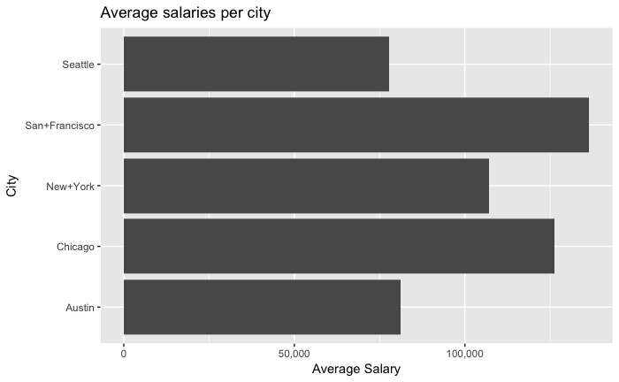

```r
avg_salary_city <- df3 %>%
        group_by(city) %>%
        summarise(mean_salary = mean(wage))
# avg_salary_city
ggplot(avg_salary_city, aes(city, mean_salary)) +
        geom_bar(stat="identity") +
        coord_flip() +
        scale_y_continuous(labels = comma) +
        labs(title="Average salaries per city", y="Average Salary", x="City")
```

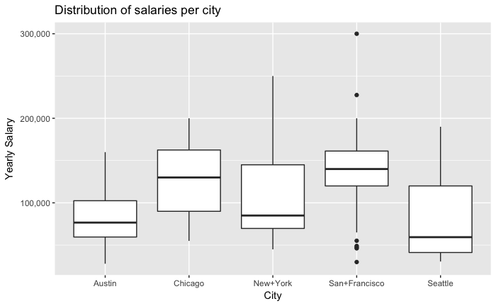

```r
df3 %>% ggplot(aes(city, wage)) +
        geom_boxplot() +
        scale_y_continuous(labels = comma) +
        labs(title="Distribution of salaries per city", x="City", y="Yearly Salary")
```

```r
# boxplot(df2$parsed_salary ~ df2$city)
```

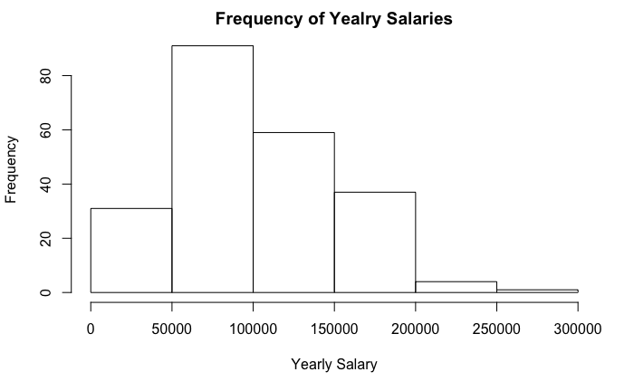

```r
# df3 %>% ggplot(aes(wage)) +
#         geom_histogram(binwidth = 12) +
#         # scale_x_continuous(labels = comma)
hist(df3$wage, breaks = 9, xlab = "Yearly Salary", main = "Frequency of Yealry Salaries")
```

```r
summary(df3$wage)
```

```
   Min. 1st Qu.  Median    Mean 3rd Qu.    Max.
  28000   64530   95000  105900  145000  300000
```

### Lets build a model to prdict whether the salary will be high or low based off of the City.

**We want to predict a binary variable - whether the salary was low or high. Compute the median salary and create a new binary variable that is true when the salary is high (above the median)**

```r
#df3$above_median <- l
```

Find which columns are above the median

```r
#which(df3$wage > median(df3$wage))
above_median <- function(x){
        med <- median(df3$wage)
        if(x > med){
                return(1)
        } else {
                return(0)
        }
}
df3$above_median <- sapply(df3$wage, above_median)
table(df3$above_median)
```

```
  0   1
112 111
```

Thought experiment: What is the baseline accuracy for this model?

```r
mean(df3$above_median)
```

```
[1] 0.4977578
```

Create a Logistic Regression model to predict High/Low salary using statsmodel. Start by ONLY using the location as a feature. Display the coefficients and write a short summary of what they mean.

```r
model <- glm(formula = "above_median ~ city", family = binomial(link = "logit"), data = df3)
summary(model)
```

```
Call:
glm(formula = "above_median ~ city", family = binomial(link = "logit"),
    data = df3)

Deviance Residuals:
   Min      1Q  Median      3Q     Max
-1.853  -1.105  -0.809   1.252   1.598

Coefficients:
                  Estimate Std. Error z value Pr(>|z|)
(Intercept)        -0.4925     0.3827  -1.287 0.198156
cityChicago         0.9520     0.5314   1.791 0.073234 .
cityNew+York        0.3192     0.4430   0.721 0.471151
citySan+Francisco   2.0123     0.5662   3.554 0.000379 ***
citySeattle        -0.4566     0.5119  -0.892 0.372417
---
Signif. codes:  0 ‘***’ 0.001 ‘**’ 0.01 ‘*’ 0.05 ‘.’ 0.1 ‘ ’ 1

(Dispersion parameter for binomial family taken to be 1)

    Null deviance: 309.14  on 222  degrees of freedom
Residual deviance: 279.19  on 218  degrees of freedom
AIC: 289.19

Number of Fisher Scoring iterations: 4
```